# Math250 HW6 Inference, etc

Author

Ilana Berlin

Published

Invalid Date

```r
library(tidyverse)
library(ISLR2)
```

### Problem 1

> The first two problems in this set refer to the ISLR2::Carseats set, which includes simulated sample data for 400 stores selling a particular brand of child carseat. We view this data as a simple random sample from a larger population. Does this data provide evidence against the company’s claim that the average price of their own seats is $110? Follow all best practices from class, including hypotheses, a relevant visualization, and a conclusion in non-technical language.

Null hypothesis: $H: \mu = 100$

Alternative: $H_a: \mu \ne 100$

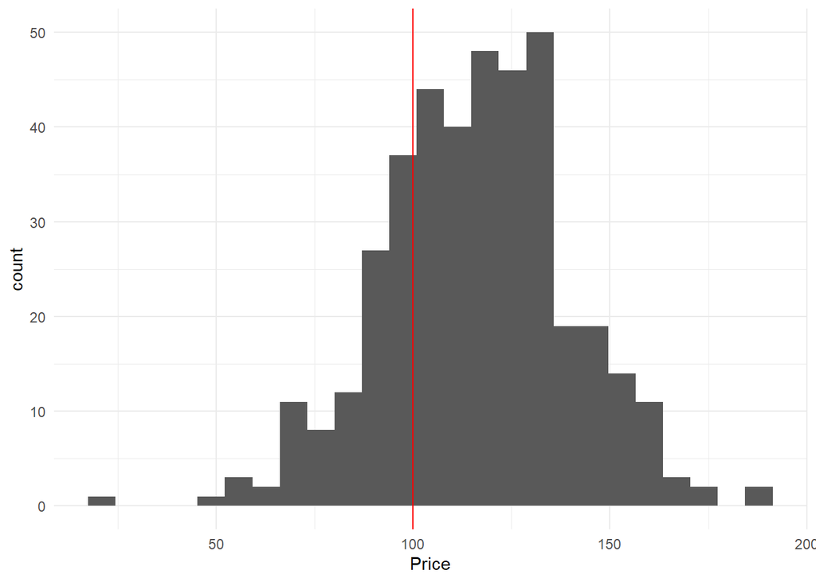

```r
Carseats %>%
  ggplot(aes(x = Price)) +
  geom_histogram(bins = 25) +
  geom_vline(xintercept = 100,
             color = "red") +
  theme_minimal()
```

```r
Carseats$Price %>%
  t.test(mu = 100)
```

```
    One Sample t-test

data:  .
t = 13.342, df = 399, p-value < 2.2e-16
alternative hypothesis: true mean is not equal to 100
95 percent confidence interval:
 113.4677 118.1223
sample estimates:
mean of x
  115.795
```

The average price of car seats is not $100 because if it was then it would be incredibly rare to get data like ours.

### Problem 2

> Compute a level 90% confidence interval for the mean competitor price in the population from which this sample is drawn. What is the sample mean? What is the margin of error?

```r
Carseats$CompPrice %>%
  t.test(conf.level = .90)
```

```
    One Sample t-test

data:  .
t = 163, df = 399, p-value < 2.2e-16
alternative hypothesis: true mean is not equal to 0
90 percent confidence interval:
 123.7109 126.2391
sample estimates:
mean of x
  124.975
```

### Problem 3

> Watch my video on contingency tables. Use these tools to create a table with counts of penguin species and home islands in the penguins set. Include marginal counts in your table.

```r
t <- table(penguins$species,
      penguins$island)
addmargins(t)
```

```
            Biscoe Dream Torgersen Sum
  Adelie        44    56        52 152
  Chinstrap      0    68         0  68
  Gentoo       124     0         0 124
  Sum          168   124        52 344
```

### Problem 4

> Push your solutions to this set to your GitHub page, including both the Quarto source and the rendered html. Use file names of the form, “math250_nov5_yourname.” Provide a clickable link to the repository on your personal GitHub where these files can be found.

[Ilana Berlin Github - Math250 Sandbox](https://github.com/IlanaB11/Math250_GithubSandbox)